# Project 2

Joey Chen and John Williams

10/24/2021

# Introduction

This project is a simple walk-through of the data science process:

[interactive chart not shown]

# Data Preparation

```r
# read data
news_data <- read_csv("./OnlineNewsPopularity.csv")

# data cleaning
world_news_data <- news_data %>%
                   # subset data by data channel
                   filter(data_channel_is_world == 1) %>%
                   # remove data channel variables
                   select(-starts_with("data_channel_is")) %>%
                   # remove non-predictive variables
                   select(-url, -timedelta)
```

# Exploratory Data Analysis

## Distribution of Response Variable

First, we can take a look at the distribution of our response variable `shares`. We can first look at the histogram.

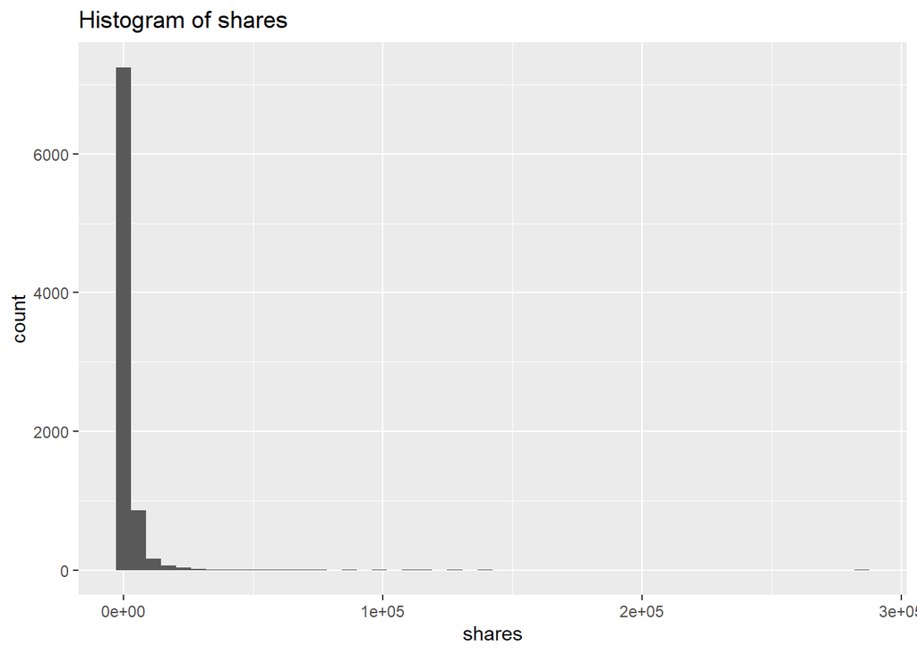

```r
# Histogram of shares
ggplot(world_news_data, aes(x=shares)) +
  geom_histogram(bins=50) +
  labs(title="Histogram of shares")
```

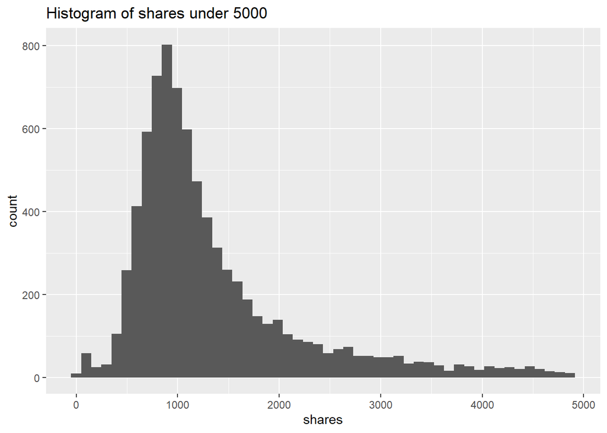

```r
# Histogram of shares < 5000
ggplot(filter(world_news_data, shares < 5000), aes(x=shares)) +
  geom_histogram(bins=50) +
  labs(title="Histogram of shares under 5000")
```

As we can see, the distribution is still heavily right skewed. So we may want to look at the distribution of `log(shares)`.

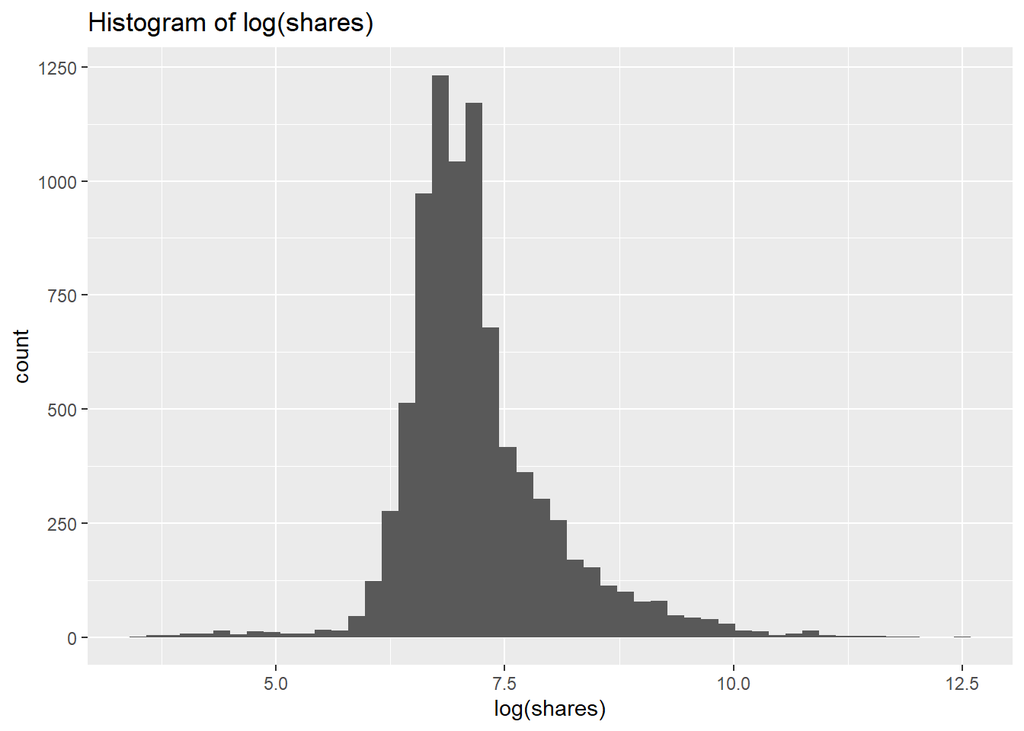

```r
# Histogram of log(shares)
ggplot(world_news_data, aes(x=log(shares))) +
  geom_histogram(bins=50) +
  labs(title="Histogram of log(shares)")
```

From the histogram we can see that the distribution is slightly right skewed. But it is much closer to normal compared to the original distribution.

We can also look at the numeric summary of `shares` vs `log(shares)`.

```r
# Numeric summary of shares
shares_summary <- world_news_data %>% summarise(Min. = min(shares),
                                                Q1 = quantile(shares, 0.25),
                                                Median = median(shares),
                                                Mean = mean(shares),
                                                SD = sd(shares),
                                                Q3 = quantile(shares, 0.75),
                                                Max = max(shares))

knitr::kable(shares_summary, digits=0, caption = "Numeric Summary of Shares")
```

Numeric Summary of Shares

| Min. | Q1 | Median | Mean | SD | Q3 | Max |
| --- | --- | --- | --- | --- | --- | --- |
| 35 | 827 | 1100 | 2288 | 6090 | 1900 | 284700 |

```r
# Numeric summary of log(shares)
log_shares_summary <- world_news_data %>% summarise(Min. = min(log(shares)),
                                                Q1 = quantile(log(shares), 0.25),
                                                Median = median(log(shares)),
                                                Mean = mean(log(shares)),
                                                SD = sd(log(shares)),
                                                Q3 = quantile(log(shares), 0.75),
                                                Max = max(log(shares)))

knitr::kable(log_shares_summary, digits=3, caption="Numeric Summary of log(Shares)")
```

Numeric Summary of log(Shares)

| Min. | Q1 | Median | Mean | SD | Q3 | Max |
| --- | --- | --- | --- | --- | --- | --- |
| 3.555 | 6.718 | 7.003 | 7.203 | 0.83 | 7.55 | 12.559 |

In addition to the histograms, we can see that the coefficient of variation (CV) is much larger in `shares` compared to `log(shares)`. This can make `shares` harder to predict. So we will continue to do EDA using `log(shares)` and will fit the models on `log(shares)` since that can also help reduce the impact of some extreme values of `shares`.

## Log(shares) by Day of Week

Let’s create a categorical variable `day_published` and determine if the mean/median number of shares changes depending on what day the article was published:

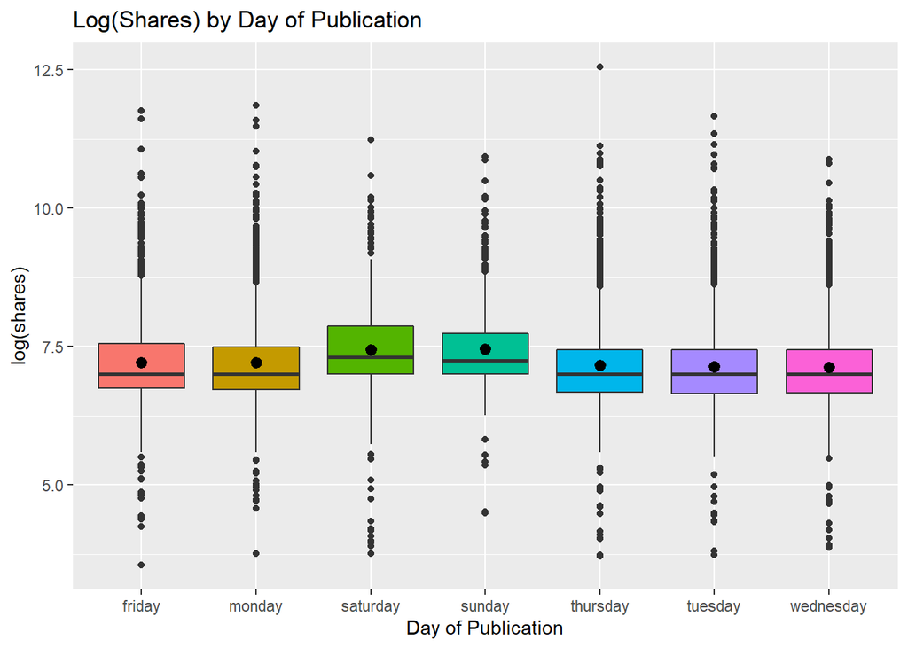

```r
world_news_data2 <- world_news_data %>%
                    pivot_longer(starts_with("weekday"),
                                 names_to = "day_published",
                                 names_prefix = "weekday_is_") %>%
                    filter(value == 1) %>%
                    select(-value)

ggplot(world_news_data2, aes(x = day_published, y = log(shares))) +
  geom_boxplot(aes(fill = day_published)) +
  stat_summary(fun.y = "mean") +
  theme(legend.position = "none") +
  labs(x = "Day of Publication",
       title = "Log(Shares) by Day of Publication")
```

After viewing the boxplot above, you should be able to determine what day (or days) have the highest mean/median shares compared to other days. The median is represented by the bold horizontal black line ithin the colored box; the mean is represented by the black dot within the colored box.

We can further see evidence of this by examining the categorical variable `is_weekend`:

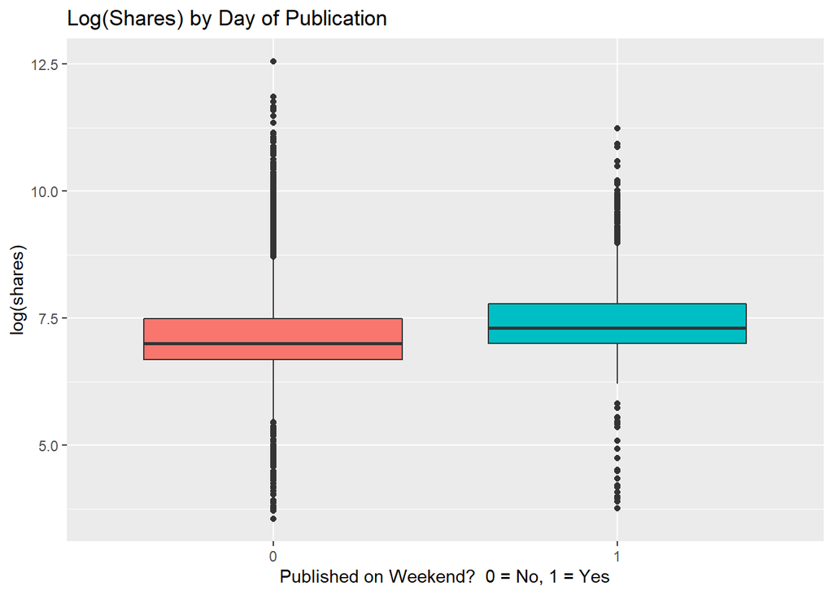

```r
ggplot(world_news_data, aes(x = as.factor(is_weekend), y = log(shares))) +
  geom_boxplot(aes(fill = as.factor(is_weekend))) +
  theme(legend.position = "none") +
  labs(x = "Published on Weekend?  0 = No, 1 = Yes",
       title = "Log(Shares) by Day of Publication")
```

## Summary by Interval

```r
tab <- world_news_data %>%
       mutate(title_subjectivity = cut(title_subjectivity,
                                       seq(-0.05, 1.05, by = 0.1))) %>%
       group_by(title_subjectivity) %>%
       summarise(mean = mean(log(shares)),
                 median = median(log(shares)),
                 n = n())

knitr::kable(tab,
             digits = 3,
             format.args = list(big.mark = ",", scientific = FALSE),
             col.names = c('Title Subjectivity', 'Mean', 'Median', 'Count'),
             caption = "Summary of Title Subjectivity")
```

Summary of Title Subjectivity

| Title Subjectivity | Mean | Median | Count |
| --- | --- | --- | --- |
| (-0.05,0.05] | 7.172 | 7.003 | 4,329 |
| (0.05,0.15] | 7.167 | 7.003 | 385 |
| (0.15,0.25] | 7.213 | 7.090 | 426 |
| (0.25,0.35] | 7.216 | 7.003 | 527 |
| (0.35,0.45] | 7.238 | 7.003 | 586 |
| (0.45,0.55] | 7.199 | 7.003 | 848 |
| (0.55,0.65] | 7.246 | 7.003 | 239 |
| (0.65,0.75] | 7.305 | 7.090 | 316 |
| (0.75,0.85] | 7.239 | 7.090 | 119 |
| (0.85,0.95] | 7.267 | 7.090 | 195 |
| (0.95,1.05] | 7.346 | 7.170 | 457 |

Similarly, we can examine `rate_negative_words`:

```r
tab <- world_news_data %>%
       mutate(rate_negative_words = cut(rate_negative_words,
                                        seq(-0.05, 1.05, by = 0.1))) %>%
       group_by(rate_negative_words) %>%
       summarise(mean = mean(log(shares)),
                 median = median(log(shares)),
                 n = n())

knitr::kable(tab,
             digits = 3,
             format.args = list(big.mark = ",", scientific = FALSE),
             col.names = c('Rate Negative Words', 'Mean', 'Median', 'Count'),
             caption = "Summary of Rate Negative Words")
```

Summary of Rate Negative Words

| Rate Negative Words | Mean | Median | Count |
| --- | --- | --- | --- |
| (-0.05,0.05] | 7.420 | 7.170 | 444 |
| (0.05,0.15] | 7.320 | 7.170 | 470 |
| (0.15,0.25] | 7.270 | 7.090 | 1,389 |
| (0.25,0.35] | 7.226 | 7.003 | 2,005 |
| (0.35,0.45] | 7.157 | 7.003 | 2,060 |
| (0.45,0.55] | 7.134 | 7.003 | 1,265 |
| (0.55,0.65] | 7.067 | 6.908 | 508 |
| (0.65,0.75] | 7.064 | 6.908 | 212 |
| (0.75,0.85] | 7.118 | 7.003 | 53 |
| (0.85,0.95] | 6.870 | 6.770 | 11 |
| (0.95,1.05] | 7.148 | 7.047 | 10 |

And `avg_positive_polarity`:

```r
tab <- world_news_data %>%
       mutate(avg_positive_polarity = cut(avg_positive_polarity,
                                          seq(0, 1, by = 0.1), right = F)) %>%
       group_by(avg_positive_polarity) %>%
       summarise(mean = mean(log(shares)),
                 median = median(log(shares)),
                 n = n())

knitr::kable(tab,
             digits = 3,
             format.args = list(big.mark = ",", scientific = FALSE),
             col.names = c('Avg Positive Polarity', 'Mean', 'Median', 'Count'),
             caption = "Summary of Average Positive Polarity")
```

Summary of Average Positive Polarity

| Avg Positive Polarity | Mean | Median | Count |
| --- | --- | --- | --- |
| [0,0.1) | 7.530 | 7.244 | 282 |
| [0.1,0.2) | 7.121 | 6.908 | 243 |
| [0.2,0.3) | 7.154 | 7.003 | 2,310 |
| [0.3,0.4) | 7.189 | 7.003 | 4,174 |
| [0.4,0.5) | 7.275 | 7.090 | 1,212 |
| [0.5,0.6) | 7.292 | 7.090 | 182 |
| [0.6,0.7) | 7.067 | 7.003 | 21 |
| [0.8,0.9) | 7.951 | 7.696 | 3 |

## Log(shares) by Number of Keywords

Is the number of keywords influential in determining the number of shares? Let’s transform `num_keywords` into a categorical variable and create a boxplot. The boxplot will show us if any particular number of keywords is related to higher number of shares.

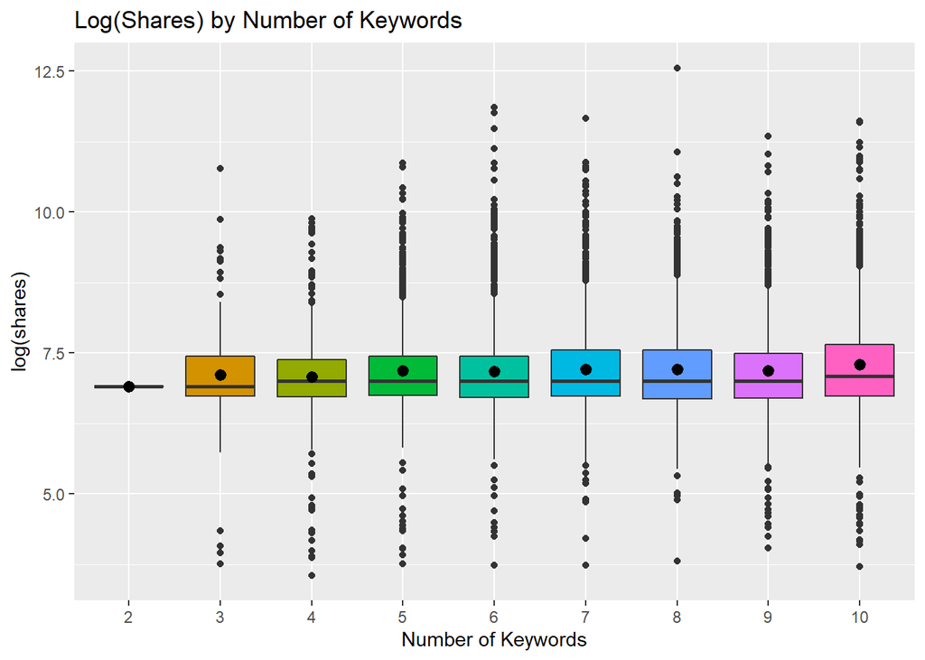

```r
ggplot(world_news_data, aes(x = as.factor(num_keywords), y = log(shares))) +
  geom_boxplot(aes(fill=as.factor(num_keywords))) +
  stat_summary(fun.y = "mean") +
  theme(legend.position = "none") +
  labs(x = "Number of Keywords",
       title = "Log(Shares) by Number of Keywords")
```

## Log(shares) by Number of Images and Videos

We can examine the impact of the number of videos and images on `log(shares)`. We can do this by looking at the scatterplots. If the points show an upward trend, then articles with more images or videos would be shared more often. If we see a negative trend then articles with more images or videos would be shared less often.

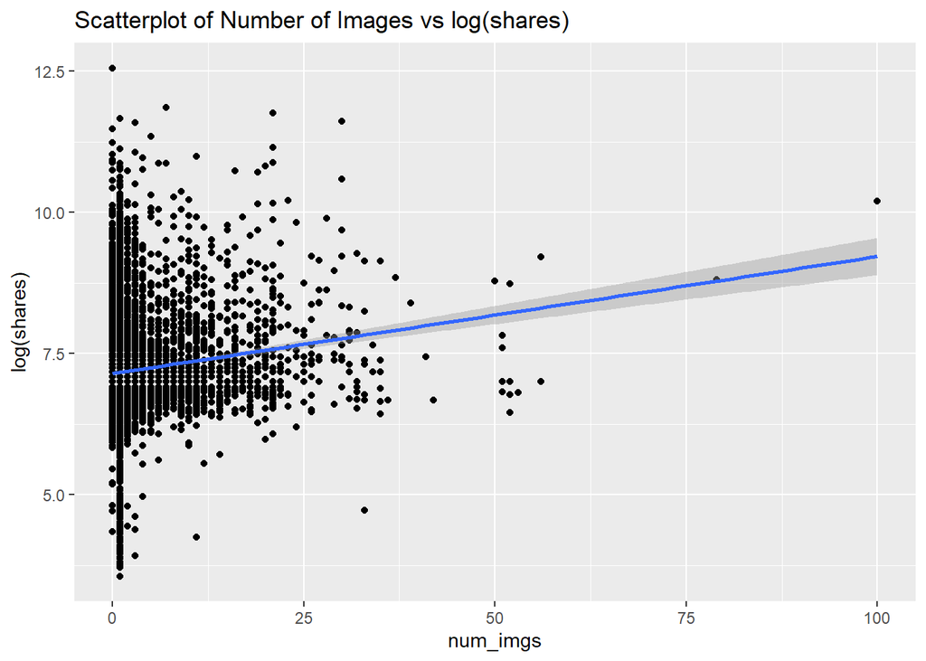

```r
# Scatterplot of num_img and log(shares)
ggplot(world_news_data, aes(x = num_imgs, y = log(shares))) +
  geom_point() +
  geom_smooth(method="lm") +
  labs(title="Scatterplot of Number of Images vs log(shares)")
```

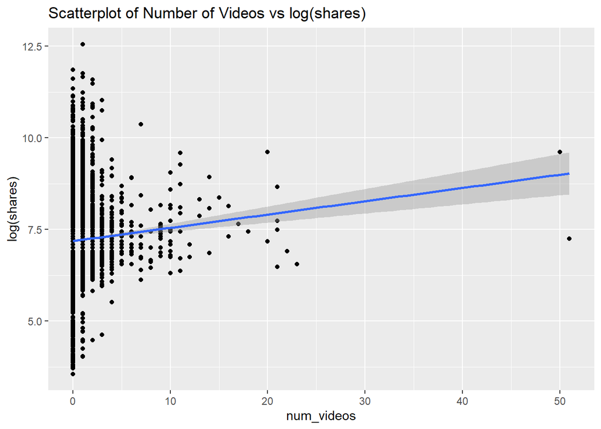

```r
# Scatterplot of num_videos and log(shares)
ggplot(world_news_data, aes(x = num_videos, y = log(shares))) +
  geom_point() +
  geom_smooth(method="lm") +
  labs(title="Scatterplot of Number of Videos vs log(shares)")
```

We can also examine the correlation coefficient (r) to observe the strength of the association. For absolute values of r, we can considered 0-0.19 as very weak, 0.2-0.39 as weak, 0.4-0.59 as moderate, 0.6-0.79 as strong and 0.8-1 as very strong correlation.

```r
# Correlation Coefficient (r) of num_imgs vs log(shares)
cor(x = world_news_data$num_imgs, y = log(world_news_data$shares))
```

```
## [1] 0.1304567
```

```r
# Correlation Coefficient (r) of num_videos vs log(shares)
cor(x = world_news_data$num_videos, y = log(world_news_data$shares))
```

```
## [1] 0.06812929
```

## Correlation of Predictors

Now, before creating our prediction models, we need to examine the correlation among predictors, as we would not want to include predictors in the model that are highly correlated. Since we have a large number of predictors, let’s attempt to subset the predictors based on measuring similar attributes.

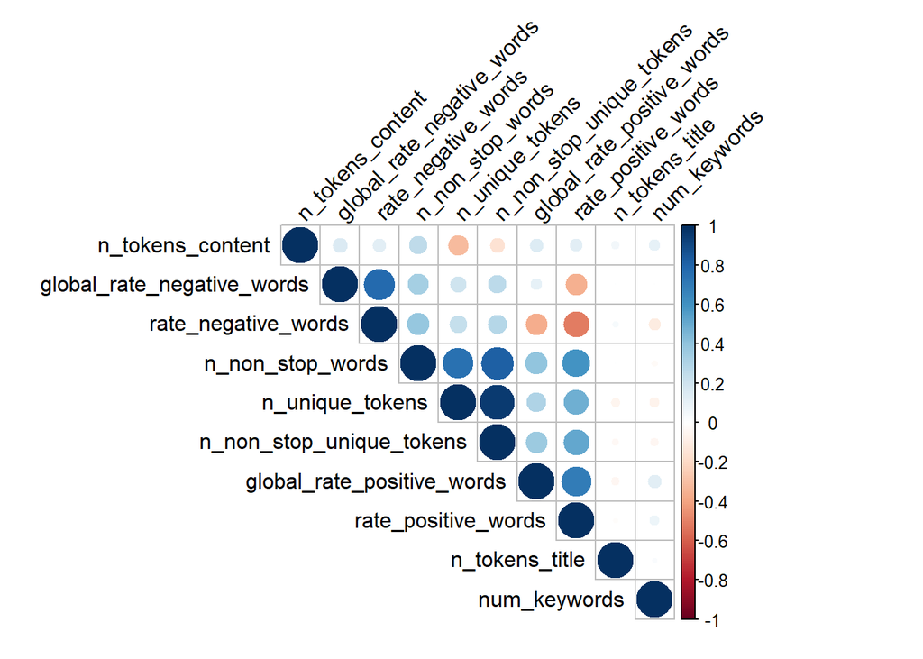

```r
# Create a correlogram for predictors that measure attributes of "tokens"
# and "words"
cor1 <- world_news_data %>% select(contains("tokens"), contains("words"))
cormatrix <- round(cor(cor1), 2)
corrplot(cormatrix, type = "upper", order = "hclust",
         tl.col = "black", tl.srt = 45)
```

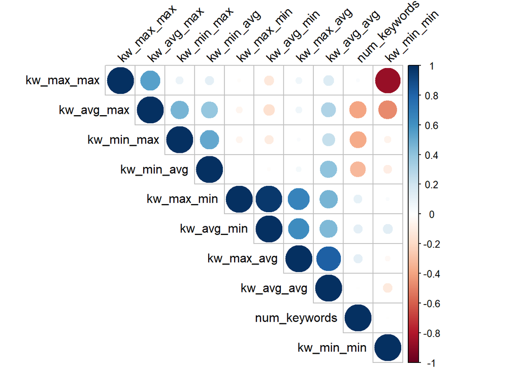

```r
# Create a correlogram for predictors that measure attributes of keywords
cor2 <- world_news_data %>% select(contains("keywords"), contains("kw"))
cormatrix <- round(cor(cor2), 2)
corrplot(cormatrix, type = "upper", order = "hclust",
         tl.col = "black", tl.srt = 45)
```

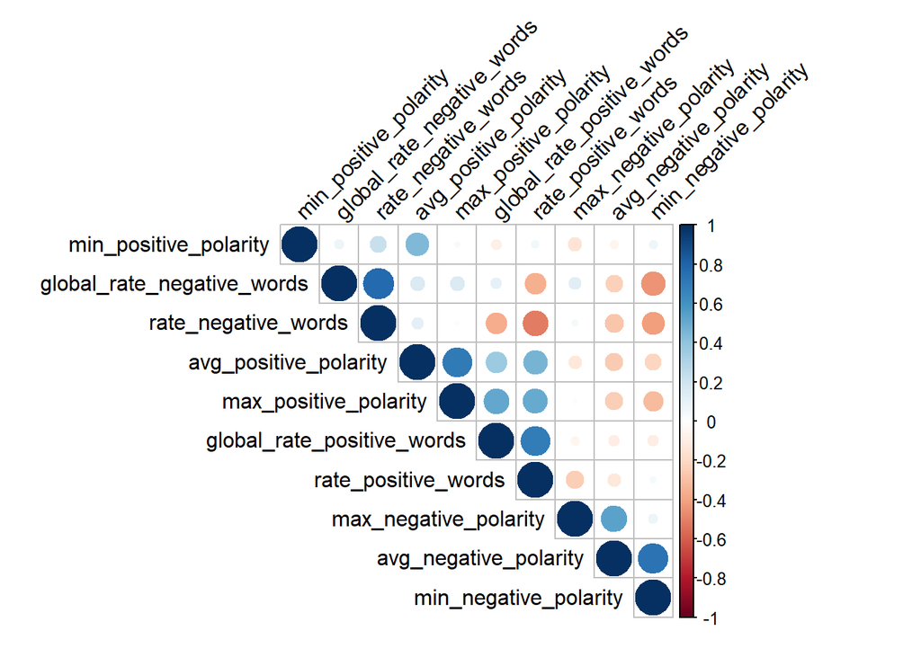

```r
# Create a correlogram for predictors that measure attributes of "positve" and
# "negative" connotation
cor3 <- world_news_data %>% select(contains("positive"), contains("negative"))
cormatrix <- round(cor(cor3), 2)
corrplot(cormatrix, type = "upper", order = "hclust",
         tl.col = "black", tl.srt = 45)
```

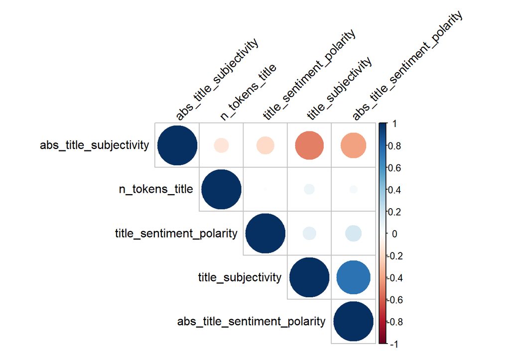

```r
# Create a correlogram for predictors that measure attributes of article titles
cor4 <- world_news_data %>% select(contains("title"))
cormatrix <- round(cor(cor4), 2)
corrplot(cormatrix, type = "upper", order = "hclust",
         tl.col = "black", tl.srt = 45)
```

# Modeling

```r
set.seed(31415)

partition <- createDataPartition(y = world_news_data$shares,
                                 p= 0.7,
                                 list = FALSE)
world_news_train <- world_news_data[partition,]
world_news_test <- world_news_data[-partition,]
```

## Linear Model #1

```r
lm1Fit <- lm(log(shares) ~ n_tokens_title +
                     n_non_stop_words +
                     num_hrefs +
                     num_imgs +
                     num_videos +
                     average_token_length +
                     kw_min_min +
                     kw_min_avg +
                     kw_max_avg +
                     kw_avg_avg +
                     self_reference_avg_sharess +
                     weekday_is_monday +
                     weekday_is_tuesday +
                     weekday_is_wednesday +
                     weekday_is_thursday +
                     weekday_is_friday +
                     LDA_00 +
                     LDA_02 +
                     global_subjectivity +
                     title_sentiment_polarity +
                     I(n_tokens_title^2) +
                     I(num_videos^2) +
                     I(average_token_length^2) +
                     I(kw_min_avg^2) +
                     I(kw_avg_avg^2) +
                     I(self_reference_avg_sharess^2) +
                     I(title_sentiment_polarity^2) +
                     num_hrefs:num_imgs +
                     kw_min_min:weekday_is_tuesday +
                     n_tokens_title:num_imgs,
            data = world_news_train)

summary(lm1Fit)
```

```
##
## Call:
## lm(formula = log(shares) ~ n_tokens_title + n_non_stop_words +
##     num_hrefs + num_imgs + num_videos + average_token_length +
##     kw_min_min + kw_min_avg + kw_max_avg + kw_avg_avg + self_reference_avg_sharess +
##     weekday_is_monday + weekday_is_tuesday + weekday_is_wednesday +
##     weekday_is_thursday + weekday_is_friday + LDA_00 + LDA_02 +
##     global_subjectivity + title_sentiment_polarity + I(n_tokens_title^2) +
##     I(num_videos^2) + I(average_token_length^2) + I(kw_min_avg^2) +
##     I(kw_avg_avg^2) + I(self_reference_avg_sharess^2) + I(title_sentiment_polarity^2) +
##     num_hrefs:num_imgs + kw_min_min:weekday_is_tuesday + n_tokens_title:num_imgs,
##     data = world_news_train)
##
## Residuals:
##     Min      1Q  Median      3Q     Max
## -3.4534 -0.4405 -0.1163  0.3011  5.0505
##
## Coefficients:
##                                   Estimate Std. Error t value Pr(>|t|)
## (Intercept)                      7.328e+00  2.176e-01  33.681  < 2e-16 ***
## n_tokens_title                  -6.580e-02  3.474e-02  -1.894 0.058300 .
## n_non_stop_words                 1.365e+01  2.703e+00   5.049 4.57e-07 ***
## num_hrefs                        9.835e-03  1.366e-03   7.198 6.88e-13 ***
## num_imgs                         5.343e-02  1.126e-02   4.745 2.13e-06 ***
## num_videos                       3.690e-02  9.923e-03   3.718 0.000202 ***
## average_token_length            -5.539e+00  1.118e+00  -4.953 7.51e-07 ***
## kw_min_min                       1.452e-03  2.080e-04   6.981 3.27e-12 ***
## kw_min_avg                      -2.566e-04  4.441e-05  -5.778 7.96e-09 ***
## kw_max_avg                      -2.003e-05  7.118e-06  -2.814 0.004903 **
## kw_avg_avg                       2.836e-04  3.351e-05   8.464  < 2e-16 ***
## self_reference_avg_sharess       7.922e-06  1.234e-06   6.418 1.49e-10 ***
## weekday_is_monday               -2.396e-01  3.804e-02  -6.299 3.22e-10 ***
## weekday_is_tuesday              -2.655e-01  3.774e-02  -7.034 2.23e-12 ***
## weekday_is_wednesday            -3.059e-01  3.704e-02  -8.259  < 2e-16 ***
## weekday_is_thursday             -2.706e-01  3.696e-02  -7.320 2.82e-13 ***
## weekday_is_friday               -2.364e-01  3.870e-02  -6.107 1.08e-09 ***
## LDA_00                           3.098e-01  1.109e-01   2.794 0.005219 **
## LDA_02                          -1.989e-01  5.601e-02  -3.551 0.000387 ***
## global_subjectivity              4.362e-01  1.314e-01   3.319 0.000910 ***
## title_sentiment_polarity         1.797e-01  4.341e-02   4.141 3.50e-05 ***
## I(n_tokens_title^2)              4.027e-03  1.580e-03   2.548 0.010856 *
## I(num_videos^2)                 -1.117e-03  3.893e-04  -2.870 0.004123 **
## I(average_token_length^2)        5.417e-01  1.157e-01   4.681 2.91e-06 ***
## I(kw_min_avg^2)                  1.024e-07  2.200e-08   4.654 3.32e-06 ***
## I(kw_avg_avg^2)                 -1.045e-08  3.852e-09  -2.712 0.006713 **
## I(self_reference_avg_sharess^2) -1.394e-11  2.449e-12  -5.693 1.31e-08 ***
## I(title_sentiment_polarity^2)    1.498e-01  7.145e-02   2.096 0.036124 *
## num_hrefs:num_imgs              -3.094e-04  9.603e-05  -3.221 0.001283 **
## kw_min_min:weekday_is_tuesday   -1.005e-03  4.388e-04  -2.291 0.021979 *
## n_tokens_title:num_imgs         -3.376e-03  1.027e-03  -3.285 0.001024 **
## ---
## Signif. codes:  0 '***' 0.001 '**' 0.01 '*' 0.05 '.' 0.1 ' ' 1
##
## Residual standard error: 0.7781 on 5869 degrees of freedom
## Multiple R-squared:  0.1195, Adjusted R-squared:  0.115
## F-statistic: 26.55 on 30 and 5869 DF,  p-value: < 2.2e-16
```